# Medicare Charges Prediction

#### We will be using the [Hospital Charges for Inpatients](https://www.kaggle.com/datasets/speedoheck/inpatient-hospital-charges) dataset to determine if Deep Learning has an advantage at regression modeling. This is a dataset of 163K rows of hospital charge records from 3337 physicians.

#### Our goal is to use the data to predict the average Medicare charges for physicians. Note that the original dataset has been modified to use for regression. The "Average Total Payments" field had a 98% correlation with Medicare charges, as a result it was omitted.

### Method 1: Row Level Regression

#### In this simplest example we will attempt to predict the Medicare charge for each row of data.

### Step 1: Import and Process Data

#### We will use Pandas to import the Excel file and do some exploratory data analysis

```python
import pandas as pd
import numpy as np
import warnings
import matplotlib.pyplot as plt
from sklearn.model_selection import train_test_split
warnings.simplefilter('ignore')

import seaborn as sns

sns.set_theme(style='white')
sns.set(rc={'figure.figsize':(20, 5)})
sns.set(font_scale=1.1)
```

```python
excel_file = pd.ExcelFile('providers.xlsx')
```

```python
df = excel_file.parse('original')
```

```python
df.head()
```

|  | DRG Definition | Provider Id | Provider Name | Provider Street Address | Provider City | Provider State | Provider Zip Code | Hospital Referral Region Description | Total Discharges | Average Covered Charges | y |
| --- | --- | --- | --- | --- | --- | --- | --- | --- | --- | --- | --- |
| 0 | 039 - EXTRACRANIAL PROCEDURES W/O CC/MCC | 10001 | SOUTHEAST ALABAMA MEDICAL CENTER | 1108 ROSS CLARK CIRCLE | DOTHAN | AL | 36301 | AL - Dothan | 91 | 32963.07 | 4763.73 |
| 1 | 057 - DEGENERATIVE NERVOUS SYSTEM DISORDERS W/... | 10001 | SOUTHEAST ALABAMA MEDICAL CENTER | 1108 ROSS CLARK CIRCLE | DOTHAN | AL | 36301 | AL - Dothan | 38 | 20312.78 | 3865.50 |
| 2 | 064 - INTRACRANIAL HEMORRHAGE OR CEREBRAL INFA... | 10001 | SOUTHEAST ALABAMA MEDICAL CENTER | 1108 ROSS CLARK CIRCLE | DOTHAN | AL | 36301 | AL - Dothan | 84 | 38820.39 | 9167.08 |
| 3 | 065 - INTRACRANIAL HEMORRHAGE OR CEREBRAL INFA... | 10001 | SOUTHEAST ALABAMA MEDICAL CENTER | 1108 ROSS CLARK CIRCLE | DOTHAN | AL | 36301 | AL - Dothan | 169 | 27345.10 | 5438.50 |
| 4 | 066 - INTRACRANIAL HEMORRHAGE OR CEREBRAL INFA... | 10001 | SOUTHEAST ALABAMA MEDICAL CENTER | 1108 ROSS CLARK CIRCLE | DOTHAN | AL | 36301 | AL - Dothan | 33 | 17605.51 | 3618.93 |

#### We will delete Provider Name, Street Address, City, Zip Code and Region as these variables have too much cardinality and Provider Name is largely redundant to Id.

```python
df = df[['DRG Definition', 'Provider Id', 'Provider State', ' Total Discharges ', ' Average Covered Charges ', 'y']]
```

```python
df.columns = ['DRG_Definition', 'Provider_Id', 'Provider_State', 'Total_Discharges', 'Average_Covered_Charges', 'y']
```

#### Split the dataset into a training and test set, 80/20 split. We will use a random seed to ensure reproducability. In the next analysis we will explore the value of adding sequences, as a result we will split the data by doctors instead of simply by rows.

```python
#use a random seed for reproducability
import random
random.seed(123)
```

```python
#randomly select 80% of doctors and use them as the training set, the remaining 20% will be used for testing
Xtrain_docs = random.sample(list(df['Provider_Id'].unique()), int(len(df['Provider_Id'].unique()) * 0.8))
Xtest_docs = [x for x in list(df['Provider_Id'].unique()) if x not in Xtrain_docs]
```

```python
train_keys = [int(1)]* len(Xtrain_docs)
```

```python
test_keys = [int(0)] * len(Xtest_docs)
```

```python
map_dict = Xtrain_docs +Xtest_docs
map_keys = train_keys + test_keys
map_dict2 = dict(zip(map_dict, map_keys))
```

```python
df['Test or Train'] = df['Provider_Id'].map(map_dict2)
```

```python
df['Test or Train'].value_counts()/len(df['Test or Train'])
```

```
1    0.800221
0    0.199779
Name: Test or Train, dtype: float64
```

#### We will simply label the training dataset doctors with a 1 and the test set with a 0 so that we can easily split the dataset

```python
Xtrain = df[df['Test or Train'] == 1]
Xtest = df[df['Test or Train'] == 0]
```

```python
ytrain = Xtrain[['y']]
ytest = Xtest[['y']]
Xtrain.drop(columns=['y'], inplace=True)
Xtest.drop(columns=['y'], inplace=True)
Xtrain_unscaled = Xtrain.copy()
Xtest_unscaled = Xtest.copy()
```

```python
ytrain_index = ytrain.index
ytest_index = ytest.index
```

### Feature Engineering

#### There are 100 DRG Definitions and over 50 Provider States, creating dummy variables for each would cause the size of the dataset to explode. To keep these features in the dataset without increasing the number of columns we will use mean ordering where we replace the categorical value with the ranking based on the mean of the target variable. In theory this should lead to better results, but since we are using the training set only to perform the ordering it could possibly lead to overfitting.

#### We will observe the distribution of the target variable to see if we can perform a transformation that will make it closer to normally distributed if the target variable isn't

### Normal Distributions

#### Some models, particularly linear models which have a normality assumption, benefit from having features with a "normal distribution". As a result, we will transform the target value and features to get a more normal distribution. Even for non-linear models, better separation of data may lead to better model results.

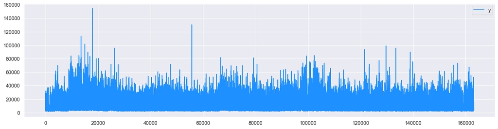

```python
ytrain.plot(color='DodgerBlue')
```

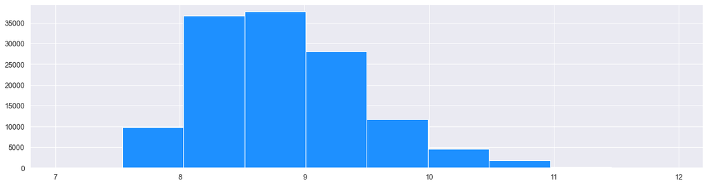

```python
plt.hist(np.log(ytrain), color='DodgerBlue')
```

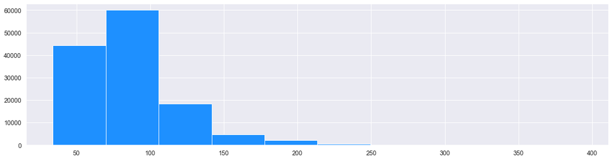

```python
plt.hist(np.sqrt(ytrain), color='DodgerBlue')
```

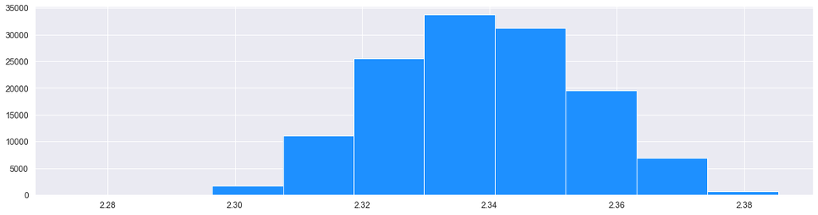

```python
import scipy.stats as stats
y_1, param = stats.yeojohnson(ytrain)
plt.hist(y_1, color='DodgerBlue')
```

#### The target is most normally distributed after the yeo-johnson transformation, we will utilize this tranformation going forward for the target variable

```python
ytrain_unscaled = ytrain.copy()
ytest_unscaled = ytest.copy()
ytrain, param = stats.yeojohnson(ytrain)
ytest = stats.yeojohnson(ytest, lmbda=param)
```

```python
ytrain = pd.DataFrame(ytrain, columns=['y'], index=ytrain_index)
ytest = pd.DataFrame(ytest, columns=['y'], index = ytest_index)
```

```python
#this formula will convert categorical variables into a category ranking based on the average value of the target
def order_categories(Xtrain, Xtest, ytrain, ytest, categories, target):
    dftrain = pd.concat([Xtrain, ytrain], axis=1).copy()
    dftest = pd.concat([Xtest, ytest], axis=1).copy()
    for col in categories:
        ordered_labels = dftrain.groupby(col).mean().sort_values(by=target).index
        ordinal_label = {k: i for i,k in enumerate(ordered_labels, 0)}
        dftrain[col] = dftrain[col].map(ordinal_label)
        dftest[col] = dftest[col].map(ordinal_label)
    dftrain.drop([target], axis=1, inplace= True)
    dftest.drop([target], axis=1, inplace=True)


    return dftrain, dftest
```

```python
Xtrain, Xtest = order_categories(Xtrain, Xtest, ytrain, ytest, ['Provider_State', 'DRG_Definition'], 'y')
Xtrain_unscaled, Xtest_unscaled = order_categories(Xtrain_unscaled, Xtest_unscaled, ytrain_unscaled, ytest_unscaled, ['Provider_State', 'DRG_Definition'], 'y')
```

```python
Xtrain = Xtrain.drop(columns=[ 'Provider_Id'])
Xtest = Xtest.drop(columns=['Provider_Id'])
```

```python
Xtrain.drop(columns=['Test or Train'], axis=1, inplace=True)
Xtest.drop(columns=['Test or Train'],axis=1, inplace=True)
```

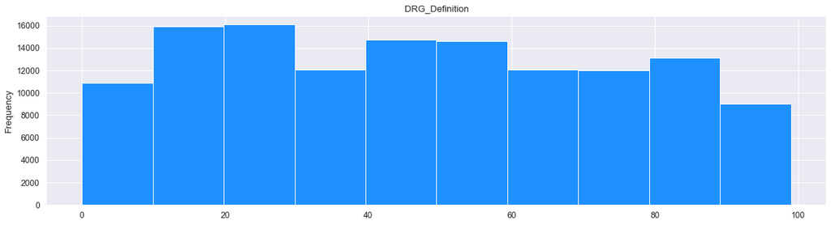

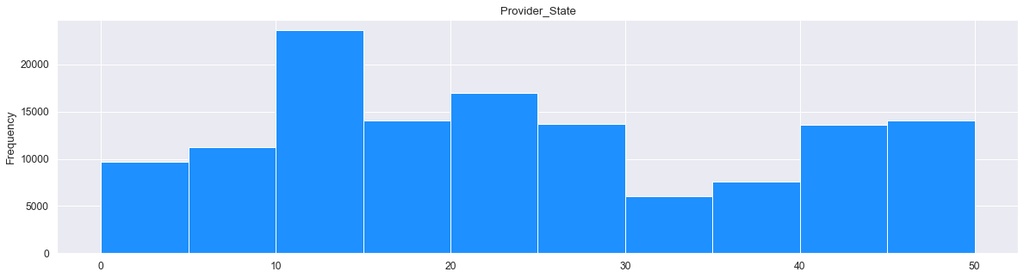

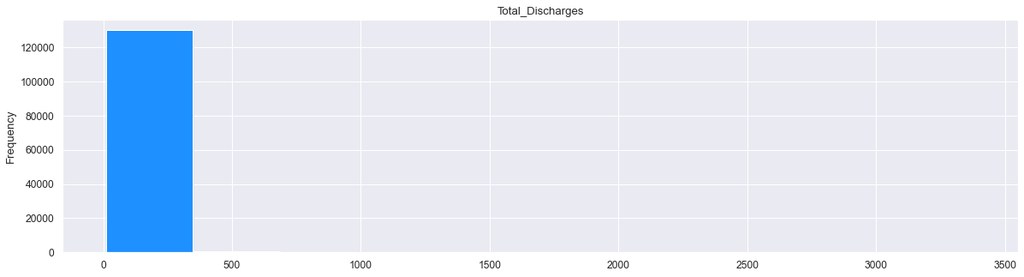

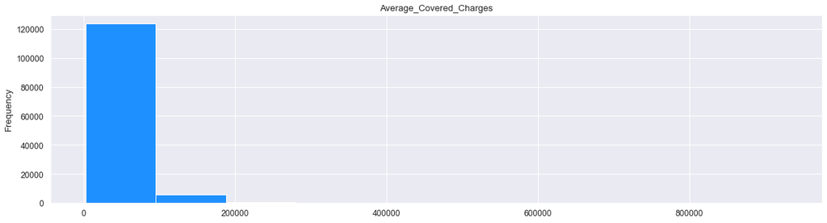

```python
for col in Xtrain.columns:
    tmp = Xtrain[col]
    tmp.plot.hist(color='DodgerBlue')
    plt.title(col)
    plt.show()
```

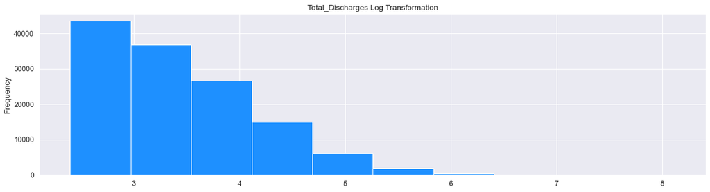

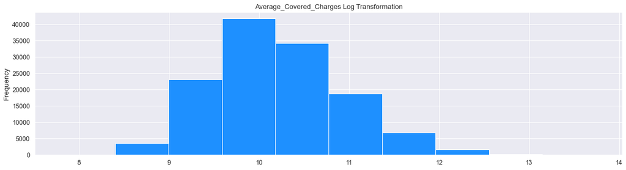

```python
for col in ['Total_Discharges', 'Average_Covered_Charges']:
    tmp = np.log(Xtrain[col])
    tmp.plot.hist(color='DodgerBlue')
    plt.title(str(col) +  ' Log Transformation')
    plt.show()
```

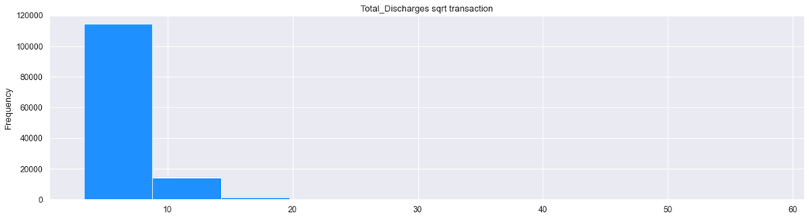

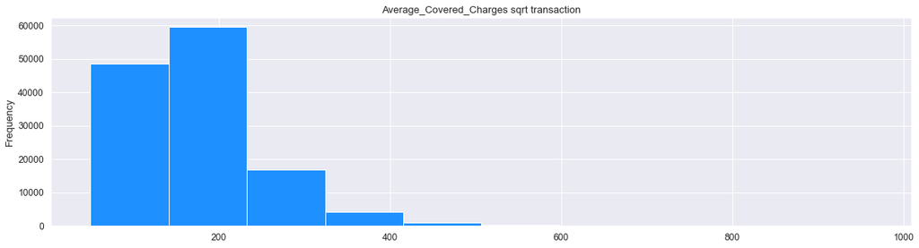

```python
for col in ['Total_Discharges', 'Average_Covered_Charges']:
    tmp = np.sqrt(Xtrain[col])
    tmp.plot.hist(color='DodgerBlue')
    plt.title(str(col) + ' sqrt transaction')
    plt.show()
```

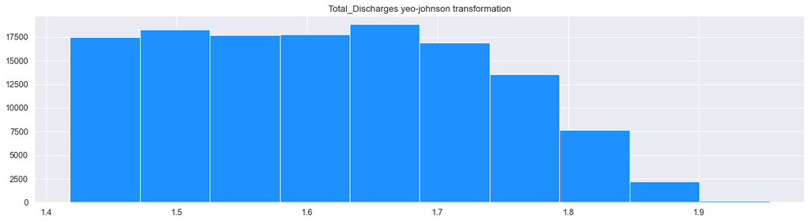

```python
for col in ['Total_Discharges']:
    tmp, param = stats.yeojohnson(Xtrain[col])
    plt.hist(tmp, color='DodgerBlue')
    plt.title(str(col) + ' yeo-johnson transformation')
    plt.show()
```

#### Based on the transformation outputs, we will utilize a log transformation for "Average Covered Charges" and a yeo-johnson transformation for "Total Discharges"

```python
Xtrain['Average_Covered_Charges'] =  np.log(Xtrain['Average_Covered_Charges'])
Xtest['Average_Covered_Charges'] =  np.log(Xtest['Average_Covered_Charges'])
Xtrain['Total_Discharges'], param =  stats.yeojohnson(Xtrain['Total_Discharges'])
Xtest['Total_Discharges'] =  stats.yeojohnson(Xtest['Total_Discharges'], lmbda = param)
```

```python
Xtrain.describe()
```

|  | DRG_Definition | Provider_State | Total_Discharges | Average_Covered_Charges |
| --- | --- | --- | --- | --- |
| count | 130488.000000 | 130488.000000 | 130488.000000 | 130488.000000 |
| mean | 47.196317 | 23.480925 | 1.617079 | 10.200579 |
| std | 27.720530 | 13.824511 | 0.118632 | 0.724180 |
| min | 0.000000 | 0.000000 | 1.418286 | 7.807673 |
| 25% | 24.000000 | 13.000000 | 1.523354 | 9.674882 |
| 50% | 47.000000 | 22.000000 | 1.615900 | 10.131954 |
| 75% | 71.000000 | 37.000000 | 1.709963 | 10.668627 |
| max | 99.000000 | 50.000000 | 1.954355 | 13.741992 |

```python
Xtrain_unscaled.describe()
```

|  | DRG_Definition | Provider_Id | Provider_State | Total_Discharges | Average_Covered_Charges | Test or Train |
| --- | --- | --- | --- | --- | --- | --- |
| count | 130488.000000 | 130488.000000 | 130488.000000 | 130488.000000 | 130488.000000 | 130488.0 |
| mean | 47.138197 | 256229.433174 | 24.325118 | 42.740122 | 35939.987097 | 1.0 |
| std | 27.823961 | 151202.489894 | 13.970093 | 51.332748 | 34789.739010 | 0.0 |
| min | 0.000000 | 10001.000000 | 0.000000 | 11.000000 | 2459.400000 | 1.0 |
| 25% | 23.000000 | 110089.000000 | 14.000000 | 17.000000 | 15912.847500 | 1.0 |
| 50% | 47.000000 | 250048.000000 | 23.000000 | 27.000000 | 25133.430000 | 1.0 |
| 75% | 70.000000 | 380061.000000 | 36.000000 | 49.000000 | 42985.870000 | 1.0 |
| max | 99.000000 | 670077.000000 | 50.000000 | 3383.000000 | 929118.900000 | 1.0 |

### Feature Scaling

#### The data is at different orders of magnitude so we will scale the data so that the larger features do not dominate on non-decision/tree based algorithms.

```python
from sklearn.preprocessing import MinMaxScaler
```

```python
scaled_features = Xtrain.copy()
scaled_features2 = Xtest.copy()

col_names = ['DRG_Definition', 'Provider_State', 'Total_Discharges', 'Average_Covered_Charges']
features = scaled_features[col_names]
features2 = scaled_features2[col_names]


scaler = MinMaxScaler().fit(features.values)
features = scaler.transform(features.values)
features2 = scaler.transform(features2.values)

Xtrain[col_names] = features
Xtest[col_names] = features2

yscaler = MinMaxScaler().fit(np.array(ytrain).reshape(-1, 1))
ytrain = yscaler.transform(np.array(ytrain).reshape(-1, 1))
ytest = yscaler.transform(np.array(ytest).reshape(-1, 1))
```

### Step 2: Machine Learning Algorithm Comparison

```python
from sklearn.metrics import mean_squared_error
from sklearn.metrics import r2_score
import tensorflow as tf
from sklearn.linear_model import LinearRegression, Ridge
from sklearn import svm
from sklearn.ensemble import AdaBoostRegressor, GradientBoostingRegressor
```

### Linear Regression

#### Unscaled

```python
lr = LinearRegression()
lr.fit(Xtrain_unscaled, ytrain_unscaled)
ytrain_pred_unscaled = lr.predict(Xtrain_unscaled)
```

```python
print('The mean squared error of the model on the training set is: ', mean_squared_error(ytrain_unscaled, ytrain_pred_unscaled ))
ytest_pred_unscaled = lr.predict(Xtest_unscaled)
print('The mean squared error of the model on the test set is: ', mean_squared_error(ytest_unscaled, ytest_pred_unscaled))
```

```
The mean squared error of the model on the training set is:  14966417.466930954
The mean squared error of the model on the test set is:  15247241.910642546
```

```python
print('The RSquared score on the training set is: ' , r2_score(ytrain_unscaled, ytrain_pred_unscaled))
print('The RSquared score on the test set is: ' , r2_score(ytest_unscaled, ytest_pred_unscaled))
```

```
The RSquared score on the training set is:  0.7195901047388806
The RSquared score on the test set is:  0.715757991533048
```

```python
testing_tracker = []
testing_tracker.append(['Lin Reg Unscaled',  mean_squared_error(ytest_unscaled, ytest_pred_unscaled), r2_score(ytest_unscaled, ytest_pred_unscaled) ])
```

#### Scaled

```python
lr = LinearRegression()
lr.fit(Xtrain, ytrain)
ytrain_pred = lr.predict(Xtrain)
```

```python
print('The mean squared error of the model on the training set is: ', mean_squared_error(ytrain, ytrain_pred ))
ytest_pred = lr.predict(Xtest)
print('The mean squared error of the model on the test set is: ', mean_squared_error(ytest, ytest_pred))
```

```
The mean squared error of the model on the training set is:  0.002380245344295491
The mean squared error of the model on the test set is:  0.002234481156281437
```

```python
print('The RSquared score on the training set is: ' , r2_score(ytrain, ytrain_pred))
print('The RSquared score on the test set is: ' , r2_score(ytest, ytest_pred))
```

```
The RSquared score on the training set is:  0.8749944988984167
The RSquared score on the test set is:  0.8832603511458895
```

```python
testing_tracker.append(['Lin Reg',  mean_squared_error(ytest, ytest_pred), r2_score(ytest, ytest_pred) ])
```

### Ridge Regression

```python
rr = Ridge()
rr.fit(Xtrain, ytrain)
ytrain_pred2 = rr.predict(Xtrain)
ytest_pred2 = rr.predict(Xtest)
```

```python
print('The mean squared error of the model on the training set is: ', mean_squared_error(ytrain, ytrain_pred2 ))
print('The mean squared error of the model on the test set is: ', mean_squared_error(ytest, ytest_pred2))
```

```
The mean squared error of the model on the training set is:  0.0023802454748357727
The mean squared error of the model on the test set is:  0.002234493490468067
```

```python
print('The RSquared score on the training set is: ' , r2_score(ytrain, ytrain_pred2))
print('The RSquared score on the test set is: ' , r2_score(ytest, ytest_pred2))
```

```
The RSquared score on the training set is:  0.8749944920427145
The RSquared score on the test set is:  0.8832597067508308
```

```python
testing_tracker.append(['Ridge Reg',  mean_squared_error(ytest, ytest_pred2), r2_score(ytest, ytest_pred2) ])
```

### AdaBoost

```python
adar = AdaBoostRegressor()
adar.fit(Xtrain, ytrain)
ytrain_pred_adar = adar.predict(Xtrain)
print(mean_squared_error(ytrain, ytrain_pred_adar))
ytest_pred_adar = adar.predict(Xtest)
```

```
0.0029407104500825047
```

```python
print('The mean squared error of the model on the training set is: ', mean_squared_error(ytrain, ytrain_pred_adar ))
print('The mean squared error of the model on the test set is: ', mean_squared_error(ytest, ytest_pred_adar))
```

```
The mean squared error of the model on the training set is:  0.0029407104500825047
The mean squared error of the model on the test set is:  0.002818091376875257
```

```python
print('The RSquared score on the training set is: ' , r2_score(ytrain, ytrain_pred_adar))
print('The RSquared score on the test set is: ' , r2_score(ytest, ytest_pred_adar))
```

```
The RSquared score on the training set is:  0.845560045191043
The RSquared score on the test set is:  0.8527698491211719
```

```python
testing_tracker.append(['AdaBoost',  mean_squared_error(ytest, ytest_pred_adar), r2_score(ytest, ytest_pred_adar) ])
```

### Gradient Boosting

```python
gbr = GradientBoostingRegressor()
gbr.fit(Xtrain, ytrain)
ytrain_pred_gbr = gbr.predict(Xtrain)
print(mean_squared_error(ytrain, ytrain_pred_gbr))
ytest_pred_gbr = gbr.predict(Xtest)
```

```
0.0019637654063100357
```

```python
print('The mean squared error of the model on the training set is: ', mean_squared_error(ytrain, ytrain_pred_gbr ))
print('The mean squared error of the model on the test set is: ', mean_squared_error(ytest, ytest_pred_gbr))
```

```
The mean squared error of the model on the training set is:  0.0019637654063100357
The mean squared error of the model on the test set is:  0.001717480402653546
```

```python
print('The RSquared score on the training set is: ' , r2_score(ytrain, ytrain_pred_gbr))
print('The RSquared score on the test set is: ' , r2_score(ytest, ytest_pred_gbr))
```

```
The RSquared score on the training set is:  0.8968671531066903
The RSquared score on the test set is:  0.9102708659878543
```

```python
testing_tracker.append(['Grad. Boosting',  mean_squared_error(ytest, ytest_pred_gbr), r2_score(ytest, ytest_pred_gbr) ])
```

### XGBoost

```python
from xgboost import XGBRegressor
```

```python
xgbru = XGBRegressor()
xgbru.fit(Xtrain_unscaled, ytrain_unscaled)
ytrain_pred_xgbr_unscaled = xgbru.predict(Xtrain_unscaled)
print(mean_squared_error(ytrain, ytrain_pred_xgbr_unscaled))
ytest_pred_xgbr_unscaled = xgbru.predict(Xtest_unscaled)
```

```
122268683.32604058
```

```python
print('The mean squared error of the model on the training set is: ', mean_squared_error(ytrain_unscaled, ytrain_pred_xgbr_unscaled ))
print('The mean squared error of the model on the test set is: ', mean_squared_error(ytest_unscaled, ytest_pred_xgbr_unscaled))
```

```
The mean squared error of the model on the training set is:  2031786.9362609182
The mean squared error of the model on the test set is:  4666202.183635841
```

```python
print('The RSquared score on the training set is: ' , r2_score(ytrain_unscaled, ytrain_pred_xgbr_unscaled))
print('The RSquared score on the test set is: ' , r2_score(ytest_unscaled, ytest_pred_xgbr_unscaled))
```

```
The RSquared score on the training set is:  0.9619325624686944
The RSquared score on the test set is:  0.9130117638086562
```

```python
testing_tracker.append(['Unscaled XGBoost',  mean_squared_error(ytest_unscaled, ytest_pred_xgbr_unscaled), r2_score(ytest_unscaled, ytest_pred_xgbr_unscaled) ])
```

```python
xgbr = XGBRegressor(learning_rate=0.1)
xgbr.fit(Xtrain, ytrain)
ytrain_pred_xgbr = xgbr.predict(Xtrain)
print(mean_squared_error(ytrain, ytrain_pred_xgbr))
ytest_pred_xgbr = xgbr.predict(Xtest)
```

```
0.001835018860734633
```

```python
print('The mean squared error of the model on the training set is: ', mean_squared_error(ytrain, ytrain_pred_xgbr ))
print('The mean squared error of the model on the test set is: ', mean_squared_error(ytest, ytest_pred_xgbr))
```

```
The mean squared error of the model on the training set is:  0.001835018860734633
The mean squared error of the model on the test set is:  0.0016267347918709236
```

```python
print('The RSquared score on the training set is: ' , r2_score(ytrain, ytrain_pred_xgbr))
print('The RSquared score on the test set is: ' , r2_score(ytest, ytest_pred_xgbr))
```

```
The RSquared score on the training set is:  0.9036286520770893
The RSquared score on the test set is:  0.9150118371560537
```

```python
testing_tracker.append(['XGBoost',  mean_squared_error(ytest, ytest_pred_xgbr), r2_score(ytest, ytest_pred_xgbr) ])
```

### Explainable Boosting

```python
from interpret.glassbox import ExplainableBoostingRegressor
ebm = ExplainableBoostingRegressor(random_state=201, interactions=0)
ebm.fit(Xtrain, ytrain)
ytrain_pred_ebm = ebm.predict(Xtrain)
print(mean_squared_error(ytrain, ytrain_pred_ebm))
ytest_pred_ebm = ebm.predict(Xtest)
```

```
0.0023669038548096784
```

```python
print('The mean squared error of the model on the training set is: ', mean_squared_error(ytrain, ytrain_pred_ebm ))
print('The mean squared error of the model on the test set is: ', mean_squared_error(ytest, ytest_pred_ebm))
```

```
The mean squared error of the model on the training set is:  0.0023669038548096784
The mean squared error of the model on the test set is:  0.0022229792633206057
```

```python
print('The RSquared score on the training set is: ' , r2_score(ytrain, ytrain_pred_ebm))
print('The RSquared score on the test set is: ' , r2_score(ytest, ytest_pred_ebm))
```

```
The RSquared score on the training set is:  0.8756951659883083
The RSquared score on the test set is:  0.8838612633270598
```

```python
testing_tracker.append(['Explain. Boost',  mean_squared_error(ytest, ytest_pred_ebm), r2_score(ytest, ytest_pred_ebm) ])
```

### TensorFlow (Feedforward Neural Network)

```python
from tensorflow.keras.models import Sequential
from tensorflow.keras.layers import Dropout, Dense, PReLU
from tensorflow.keras.initializers import GlorotNormal
from tensorflow.keras.regularizers import L1L2
import tensorflow_addons as tfa
kern_reg = L1L2(1e-5,1e-5)
x1 = GlorotNormal(seed=123)
x2 = GlorotNormal(seed=1234)
x3 = GlorotNormal(seed=12345)
x4 = GlorotNormal(seed=123456)
x5 = GlorotNormal(seed=1234567)
```

```python
import tensorflow_addons as tfa
```

```python
def model_tf(input_shp):
    model = tf.keras.Sequential([
        Dense(128, activation= 'relu', kernel_initializer=x1, bias_initializer='zeros',kernel_regularizer=kern_reg,  input_shape=(input_shp,)),
        Dense(128, activation= 'relu', kernel_initializer=x2, bias_initializer='zeros', kernel_regularizer=kern_reg),
        Dense(128, activation= 'relu', kernel_initializer=x3, bias_initializer='zeros',kernel_regularizer=kern_reg),
        Dense(128, activation= 'relu', kernel_initializer=x4, bias_initializer='zeros',kernel_regularizer=kern_reg),
        Dense(128, activation= 'relu', kernel_initializer=x5, bias_initializer='zeros',kernel_regularizer=kern_reg),
        Dense(1)
    ])

    model.compile(optimizer='adam', loss='mse', metrics=['mse', tfa.metrics.RSquare()])

    return model
```

```python
model = model_tf(Xtrain.shape[1])
```

```python
model.summary()
```

```
Model: "sequential"
_________________________________________________________________
 Layer (type)                Output Shape              Param #
=================================================================
 dense (Dense)               (None, 128)               640

 dense_1 (Dense)             (None, 128)               16512

 dense_2 (Dense)             (None, 128)               16512

 dense_3 (Dense)             (None, 128)               16512

 dense_4 (Dense)             (None, 128)               16512

 dense_5 (Dense)             (None, 1)                 129

=================================================================
Total params: 66,817
Trainable params: 66,817
Non-trainable params: 0
_________________________________________________________________
```

```python
from tensorflow.keras.callbacks import ModelCheckpoint
```

```python
checkpoint_path = 'model_checkpoints_reg1'
checkpoint = ModelCheckpoint(filepath=checkpoint_path,
                            frequency='epoch',
                            save_weights_only=True,
                            save_best_only=True,
                            monitor='loss',
                            verbose=1)
```

```python
history = model.fit(Xtrain, ytrain, batch_size=32, epochs=30,callbacks=[checkpoint], verbose=1, shuffle=True)
```

```
Epoch 1: loss improved from inf to 0.00955, saving model to model_checkpoints_reg1
Epoch 2: loss improved from 0.00955 to 0.00306, saving model to model_checkpoints_reg1
Epoch 3: loss improved from 0.00306 to 0.00277, saving model to model_checkpoints_reg1
Epoch 4: loss improved from 0.00277 to 0.00267, saving model to model_checkpoints_reg1
Epoch 5: loss improved from 0.00267 to 0.00261, saving model to model_checkpoints_reg1
Epoch 6: loss improved from 0.00261 to 0.00258, saving model to model_checkpoints_reg1
Epoch 7: loss improved from 0.00258 to 0.00256, saving model to model_checkpoints_reg1
Epoch 8: loss improved from 0.00256 to 0.00255, saving model to model_checkpoints_reg1
Epoch 9: loss improved from 0.00255 to 0.00254, saving model to model_checkpoints_reg1
Epoch 10: loss improved from 0.00254 to 0.00253, saving model to model_checkpoints_reg1
Epoch 11: loss improved from 0.00253 to 0.00252, saving model to model_checkpoints_reg1
Epoch 12: loss improved from 0.00252 to 0.00251, saving model to model_checkpoints_reg1
Epoch 13: loss improved from 0.00251 to 0.00250, saving model to model_checkpoints_reg1
Epoch 14: loss improved from 0.00250 to 0.00250, saving model to model_checkpoints_reg1
Epoch 15: loss improved from 0.00250 to 0.00248, saving model to model_checkpoints_reg1
Epoch 16: loss improved from 0.00248 to 0.00248, saving model to model_checkpoints_reg1
Epoch 17: loss improved from 0.00248 to 0.00248, saving model to model_checkpoints_reg1
Epoch 18: loss improved from 0.00248 to 0.00246, saving model to model_checkpoints_reg1
Epoch 19: loss improved from 0.00246 to 0.00246, saving model to model_checkpoints_reg1
Epoch 20: loss improved from 0.00246 to 0.00246, saving model to model_checkpoints_reg1
Epoch 21: loss did not improve from 0.00246
Epoch 22: loss improved from 0.00246 to 0.00245, saving model to model_checkpoints_reg1
Epoch 23: loss improved from 0.00245 to 0.00245, saving model to model_checkpoints_reg1
Epoch 24: loss did not improve from 0.00245
Epoch 25: loss improved from 0.00245 to 0.00245, saving model to model_checkpoints_reg1
Epoch 26: loss did not improve from 0.00245
Epoch 27: loss improved from 0.00245 to 0.00245, saving model to model_checkpoints_reg1
Epoch 28: loss improved from 0.00245 to 0.00244, saving model to model_checkpoints_reg1
Epoch 29: loss did not improve from 0.00244
Epoch 30: loss did not improve from 0.00244
```

```python
ytrain_tf_pred = model.predict(Xtrain)
ytest_tf_pred = model.predict(Xtest)
print('The mean squared error of the model on the training set is: ', mean_squared_error(ytrain, ytrain_tf_pred))
print('The mean squared error of the model on the test set is: ', mean_squared_error(ytest, ytest_tf_pred))
```

```
The mean squared error of the model on the training set is:  0.0023416042908142947
The mean squared error of the model on the test set is:  0.002137598766234591
```

```python
print('The RSquared score on the training set is: ' , r2_score(ytrain, ytrain_tf_pred))
print('The RSquared score on the test set is: ' , r2_score(ytest, ytest_tf_pred))
```

```
The RSquared score on the training set is:  0.8770238461104958
The RSquared score on the test set is:  0.8883219360970187
```

```python
testing_tracker.append(['Deep Learning',  mean_squared_error(ytest, ytest_tf_pred), r2_score(ytest, ytest_tf_pred) ])
```

```python
testing_tracker
```

```
[['Lin Reg Unscaled', 15247241.910642546, 0.715757991533048],
 ['Lin Reg', 0.002234481156281437, 0.8832603511458895],
 ['Ridge Reg', 0.002234493490468067, 0.8832597067508308],
 ['AdaBoost', 0.002818091376875257, 0.8527698491211719],
 ['Grad. Boosting', 0.001717480402653546, 0.9102708659878543],
 ['Unscaled XGBoost', 4666202.183635841, 0.9130117638086562],
 ['XGBoost', 0.0016267347918709236, 0.9150118371560537],
 ['Explain. Boost', 0.0022229792633206057, 0.8838612633270598],
 ['Deep Learning', 0.002137598766234591, 0.8883219360970187]]
```

```python
testing_tracker = pd.DataFrame(testing_tracker)
```

```python
testing_tracker.columns = ['Model', 'Mean Squared Error', 'R2']
```

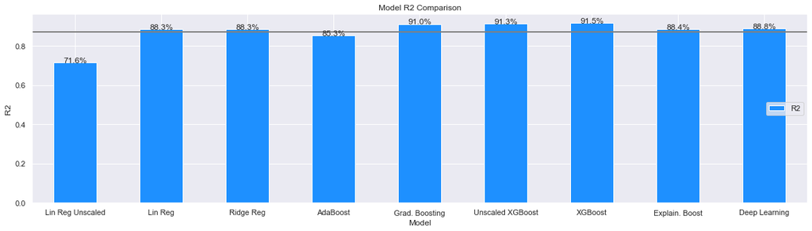

```python
sns.set(font_scale=1)
ax = testing_tracker.plot.bar(x='Model', y='R2', rot=0,  color='DodgerBlue')
ax.axhline(testing_tracker['R2'].mean(), color='gray', linewidth=2)
ax.legend(loc='right')
ax.title.set_text('Model R2 Comparison')
ax.set( ylabel='R2')
y = testing_tracker['R2']
for i in range(len(y)):
    ax.text(i, y[i], str(int(round(y[i],3)* 1000)/10) + '%', ha='center')
```

### Step 3: Feature Importance

### Explainable Boosting Machine Feature Importance

```python
from interpret import show

ebm_global = ebm.explain_global()
show(ebm_global)
```

[interactive chart not shown]

### XGBoost Shapley Values

```python
import shap

explainer = shap.TreeExplainer(xgbr)
shap_values = explainer(Xtrain)
```

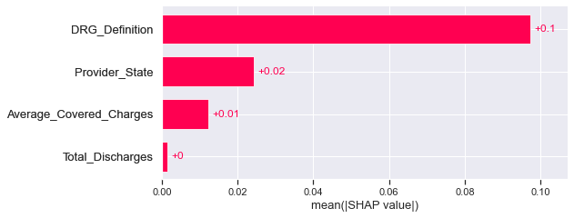

```python
shap.plots.bar(shap_values, max_display=20)
```

### Deep Learning Shapley Values

```python
explainer = shap.KernelExplainer(model, Xtrain.iloc[:50,:])
```

```python
shap_values = explainer.shap_values(Xtrain[:1000], nsamples=500)
```

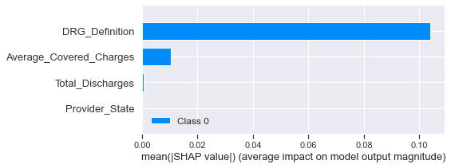

```python
shap.summary_plot(shap_values, plot_type='bar',max_display=20, feature_names = Xtrain.columns)
```